# WHITE WINE QUALITY “SRIJON SARKAR”

> In this dataset, we will be exploring the different features of white wine. We shall compare the different attributes with the quality of the wine itself and try to learn which features are most correlated with it.

# Univariate Plots Section

```
## 'data.frame':    4898 obs. of  13 variables:
##  $ X                   : int  1 2 3 4 5 6 7 8 9 10 ...
##  $ fixed.acidity       : num  7 6.3 8.1 7.2 7.2 8.1 6.2 7 6.3 8.1 ...
##  $ volatile.acidity    : num  0.27 0.3 0.28 0.23 0.23 0.28 0.32 0.27 0.3 0.22 ...
##  $ citric.acid         : num  0.36 0.34 0.4 0.32 0.32 0.4 0.16 0.36 0.34 0.43 ...
##  $ residual.sugar      : num  20.7 1.6 6.9 8.5 8.5 6.9 7 20.7 1.6 1.5 ...
##  $ chlorides           : num  0.045 0.049 0.05 0.058 0.058 0.05 0.045 0.045 0.049 0.044 ...
##  $ free.sulfur.dioxide : num  45 14 30 47 47 30 30 45 14 28 ...
##  $ total.sulfur.dioxide: num  170 132 97 186 186 97 136 170 132 129 ...
##  $ density             : num  1.001 0.994 0.995 0.996 0.996 ...
##  $ pH                  : num  3 3.3 3.26 3.19 3.19 3.26 3.18 3 3.3 3.22 ...
##  $ sulphates           : num  0.45 0.49 0.44 0.4 0.4 0.44 0.47 0.45 0.49 0.45 ...
##  $ alcohol             : num  8.8 9.5 10.1 9.9 9.9 10.1 9.6 8.8 9.5 11 ...
##  $ quality             : int  6 6 6 6 6 6 6 6 6 6 ...
```

> We have got 4898 samples in our dataset and each sample has 13 observations. One thing we notice upon seeing the structure of the dataset is that the output variable(quality) , even though it always takes discrete values(0-10), is not a factor variable. It makes sense to convert it into a factor variable.

```
##  Factor w/ 7 levels "3","4","5","6",..: 4 4 4 4 4 4 4 4 4 4 ...
```

```
##        X        fixed.acidity    volatile.acidity  citric.acid
##  Min.   :   1   Min.   : 3.800   Min.   :0.0800   Min.   :0.0000
##  1st Qu.:1225   1st Qu.: 6.300   1st Qu.:0.2100   1st Qu.:0.2700
##  Median :2450   Median : 6.800   Median :0.2600   Median :0.3200
##  Mean   :2450   Mean   : 6.855   Mean   :0.2782   Mean   :0.3342
##  3rd Qu.:3674   3rd Qu.: 7.300   3rd Qu.:0.3200   3rd Qu.:0.3900
##  Max.   :4898   Max.   :14.200   Max.   :1.1000   Max.   :1.6600
##
##  residual.sugar     chlorides       free.sulfur.dioxide
##  Min.   : 0.600   Min.   :0.00900   Min.   :  2.00
##  1st Qu.: 1.700   1st Qu.:0.03600   1st Qu.: 23.00
##  Median : 5.200   Median :0.04300   Median : 34.00
##  Mean   : 6.391   Mean   :0.04577   Mean   : 35.31
##  3rd Qu.: 9.900   3rd Qu.:0.05000   3rd Qu.: 46.00
##  Max.   :65.800   Max.   :0.34600   Max.   :289.00
##
##  total.sulfur.dioxide    density             pH          sulphates
##  Min.   :  9.0        Min.   :0.9871   Min.   :2.720   Min.   :0.2200
##  1st Qu.:108.0        1st Qu.:0.9917   1st Qu.:3.090   1st Qu.:0.4100
##  Median :134.0        Median :0.9937   Median :3.180   Median :0.4700
##  Mean   :138.4        Mean   :0.9940   Mean   :3.188   Mean   :0.4898
##  3rd Qu.:167.0        3rd Qu.:0.9961   3rd Qu.:3.280   3rd Qu.:0.5500
##  Max.   :440.0        Max.   :1.0390   Max.   :3.820   Max.   :1.0800
##
##     alcohol      quality
##  Min.   : 8.00   3:  20
##  1st Qu.: 9.50   4: 163
##  Median :10.40   5:1457
##  Mean   :10.51   6:2198
##  3rd Qu.:11.40   7: 880
##  Max.   :14.20   8: 175
##                  9:   5
```

> Now,let us plot a histogram of the different qualities of the white wine.

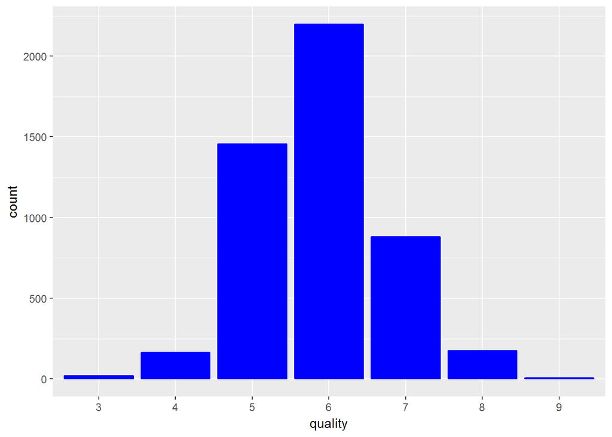

> What we observe here is that although wine quality ranges from 0-10, we only have qualities in 3-9 in our dataset. Also, count of quality 3 and 9 wine is very low. The highest count of white wine is of quality 6.

> Now let us plot a histogram of the pH levels of all the samples.

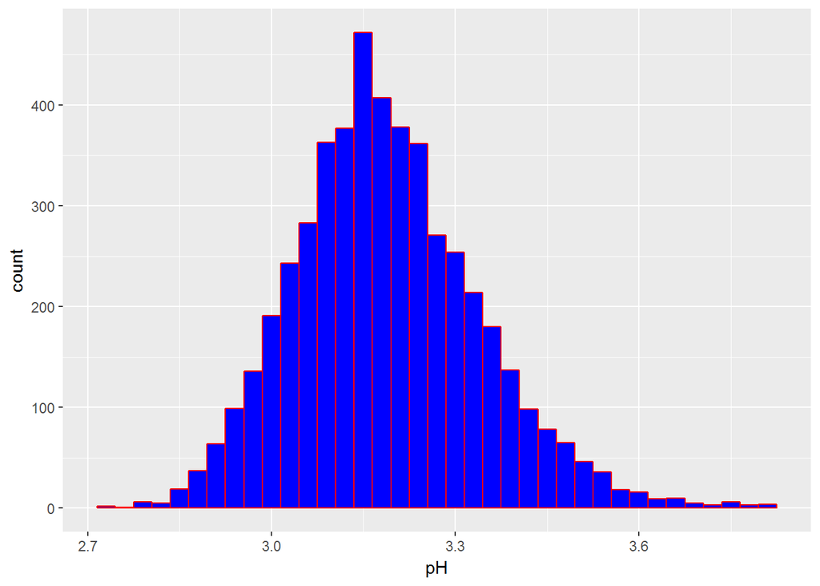

```
##    Min. 1st Qu.  Median    Mean 3rd Qu.    Max.
##   2.720   3.090   3.180   3.188   3.280   3.820
```

> Now lets look at the distribution of density in the different wine samples.

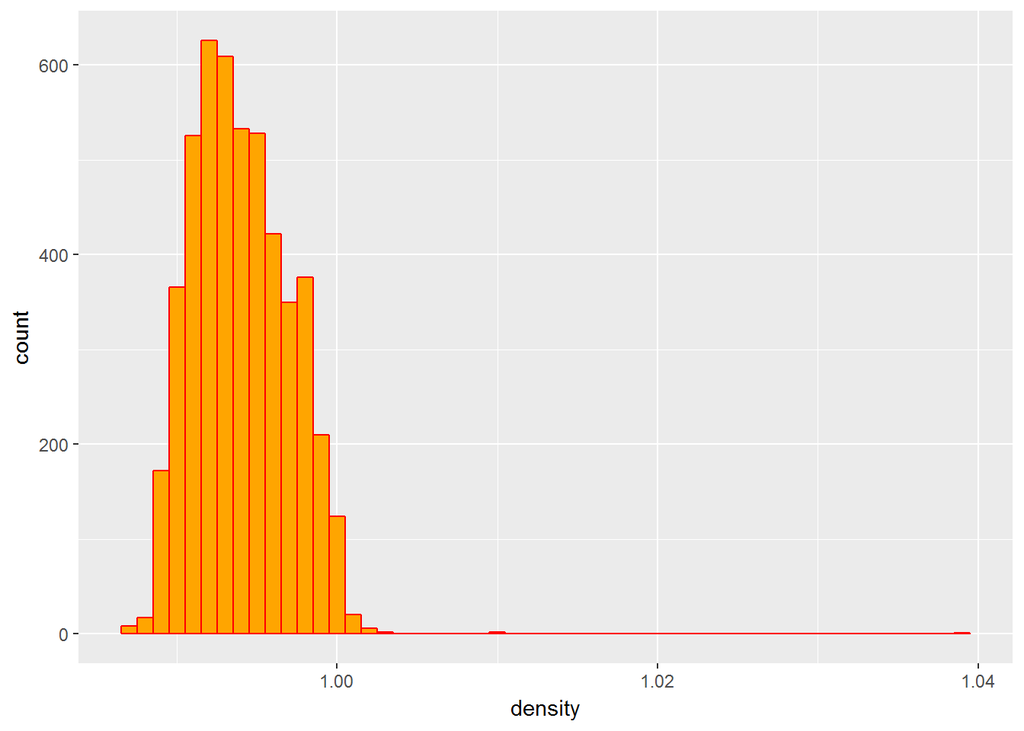

> We can get a decent idea of the distribution here, but most values are centered just below 1, and rest of the plot has outliers.

```
##    Min. 1st Qu.  Median    Mean 3rd Qu.    Max.
##  0.9871  0.9917  0.9937  0.9940  0.9961  1.0390
```

> As we see here, the minimum value of density is 0.987 and maximum value is 1.039, which is very far away. Let us plot only those points above 0.98 and below 1.01.

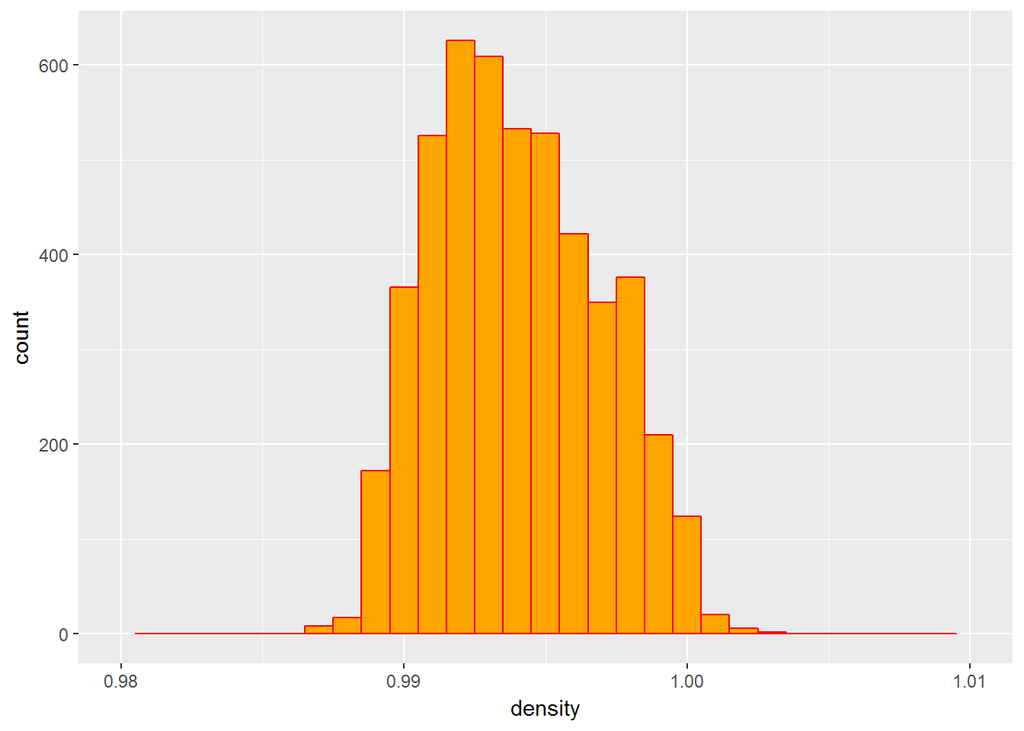

> This plot is a better visualisation. We notice that most peaks are just above 0.99, and all counts above 200 are between 0.99 and 1.

Let us plot the histogram of alcohol variable and see its distribution.

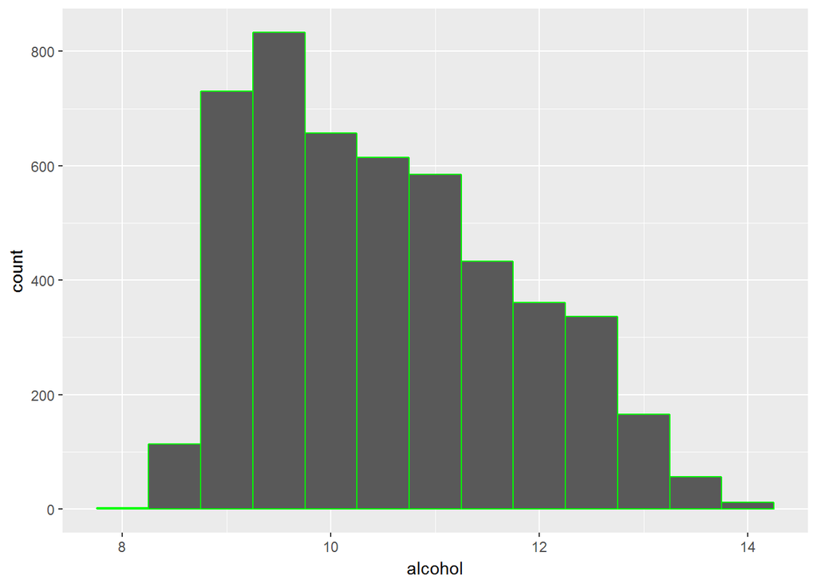

> This histogram tells us that a large no. of our samples have alcohol% just below 10. All the alcohol% values lie between 8 and 14. Let us plot a boxplot and compare the values with different qualities of white wine.

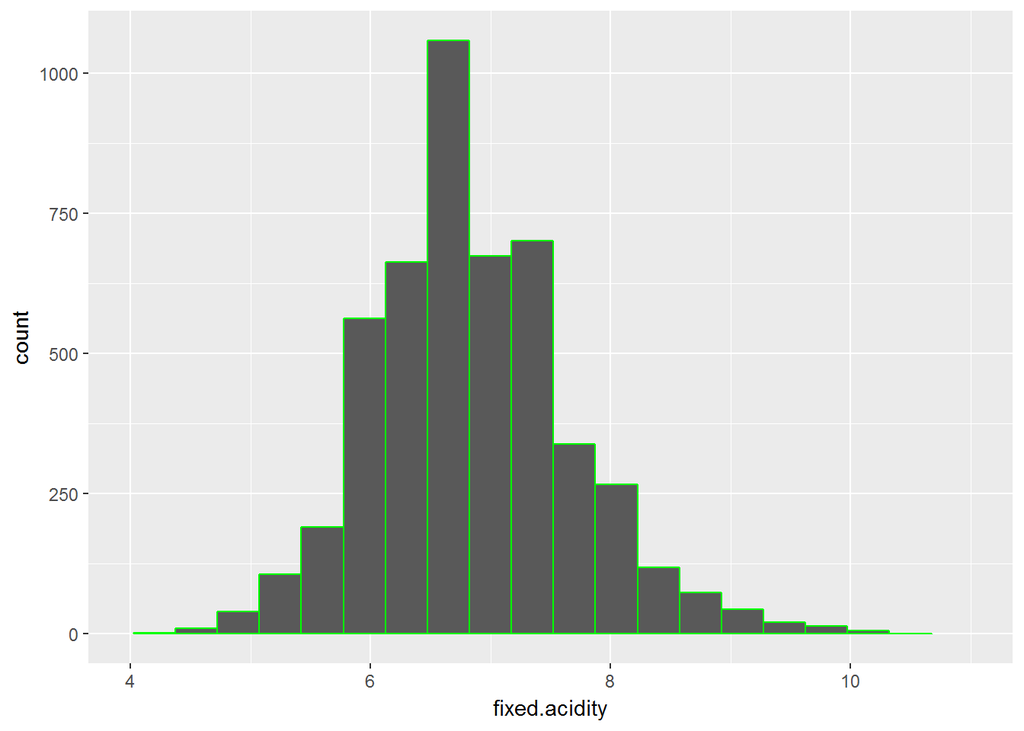

> Most white wine samples in our dataset have fixed acidity levels around 6.5 g/dm^3.

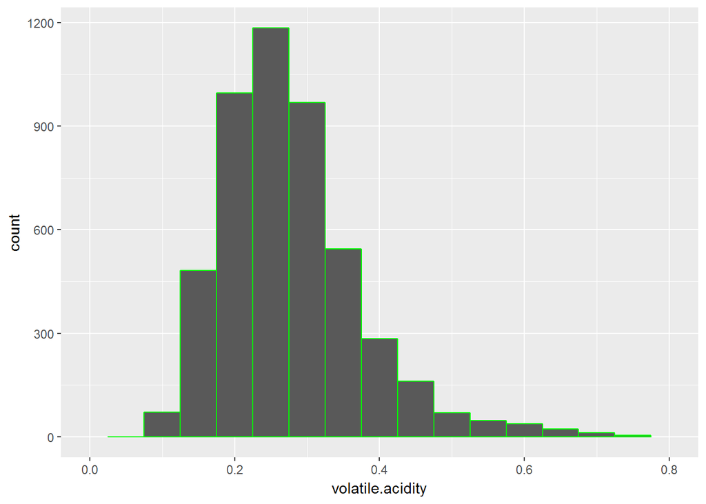

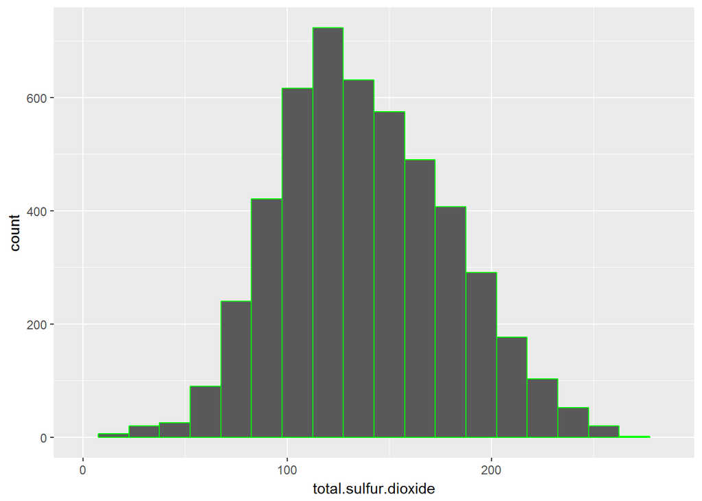

> It refers to the total sulfur dioxide contents of white wine, including free and bound forms. It is centered around 120 mg / dm^3.

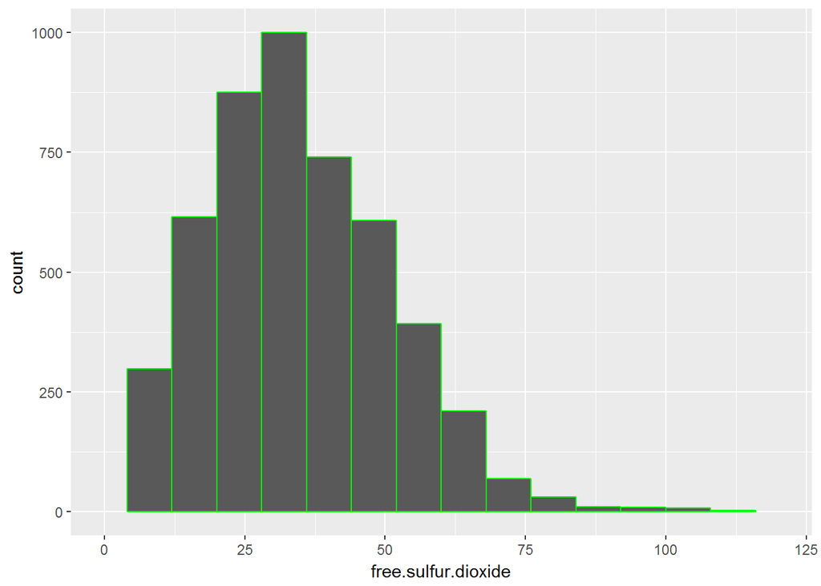

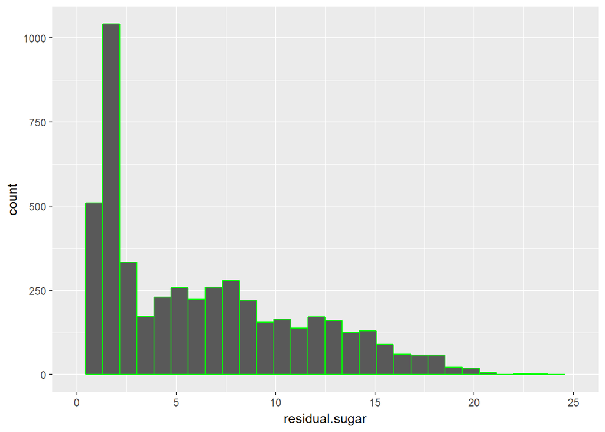

> The residual sugar is measured in g / dm^3 , and we can see that maximum samples in our dataset have residual sugar amount below 2.5 .

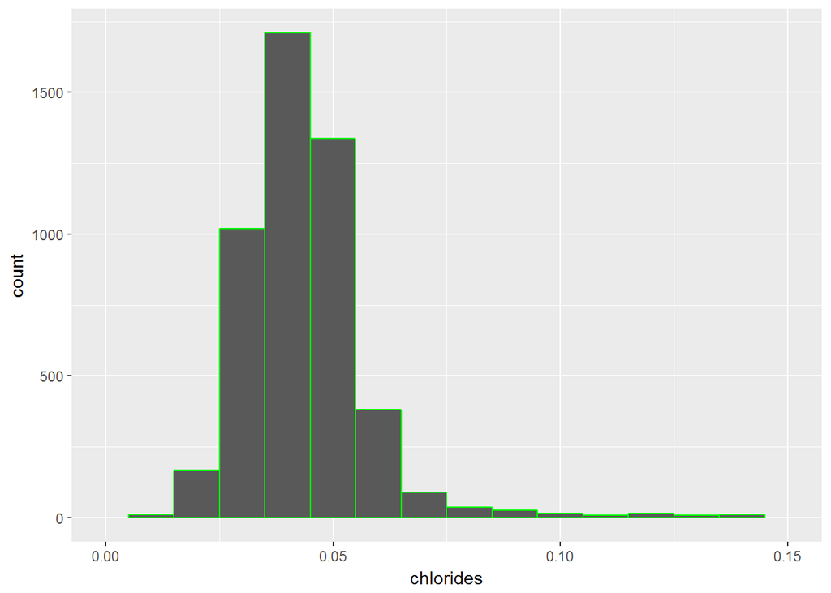

> Chlorides is the amount of salt in wine, measured in g/ dm^3, and most of our samples have below 0.05

# Univariate Analysis

### What is the structure of your dataset?

> The white wine quality dataset has 4898 no. of samples, with each sample associated with 12 features( +1 which is indices). The output variable is the quality of each sample which can ideally have a number from 0 to 10, however our dataset only has samples qualities lying between 3 and 9. The maximum no. of samples belong to quality 6.

### What is/are the main feature(s) of interest in your dataset?

> I am interested mostly in the quality factor, and the features which help in driving that quality upwards, that is which variables are highly correlated with the quality factor.

### What other features in the dataset do you think will help support your investigation into your feature(s) of interest?

> The alcohol% , pH and density seem to be important variables with respect to determining the quality, and hence will concentrate on them. But will look for correlations in other variables too.

### Did you create any new variables from existing variables in the dataset?

> No, I did not create any new variable.

### Of the features you investigated, were there any unusual distributions? Did you perform any operations on the data to tidy, adjust, or change the form of the data? If so, why did you do this?

> Yes, I converted the type of data for the quality factor. Since it took a discrete value from the set(0,10), I converted it into a factor variable. That’s the only change I did in the dataset.

# Bivariate Plots Section

> Let us first plot fixed.acidity vs volatile.acidity, and check if there is any correlation between the two.

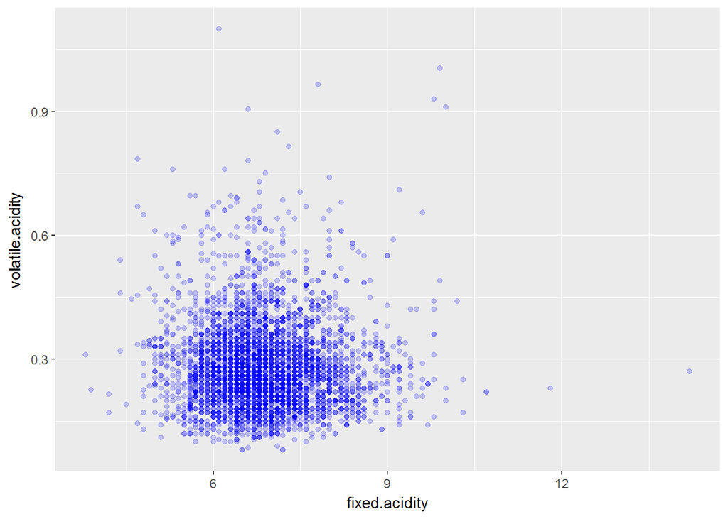

> Based on this plot, it doesn’t seem that there is any correlation in between the variables. Let us find the correlation coeficient of the same.

```
##
##  Pearson's product-moment correlation
##
## data:  df$fixed.acidity and df$volatile.acidity
## t = -1.5886, df = 4896, p-value = 0.1122
## alternative hypothesis: true correlation is not equal to 0
## 95 percent confidence interval:
##  -0.050671536  0.005312543
## sample estimates:
##         cor
## -0.02269729
```

> The value of correlation coefficient is too low to be considered significant. Hence we can conclude that there isn’t any correlation between them.

> Let us see if the density changes along with the quality of wine. Let us make a box plot for the different wine qualities.

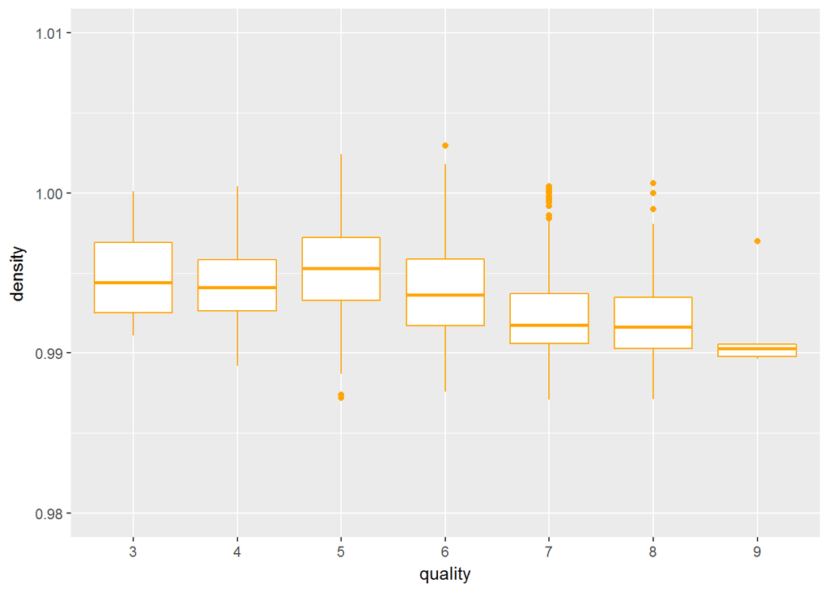

> We can see that the median value of density of the white wine generally gets lower as the quality of the wine increases. Although there are quite a few outliers of lower quality which also show similar density as higher quality wines. Let us find the actual numerical differences in the median values.

> Density stats grouped by different qualities.

```
## df$quality: 3
##    Min. 1st Qu.  Median    Mean 3rd Qu.    Max.
##  0.9911  0.9925  0.9944  0.9949  0.9969  1.0001
## --------------------------------------------------------
## df$quality: 4
##    Min. 1st Qu.  Median    Mean 3rd Qu.    Max.
##  0.9892  0.9926  0.9941  0.9943  0.9958  1.0004
## --------------------------------------------------------
## df$quality: 5
##    Min. 1st Qu.  Median    Mean 3rd Qu.    Max.
##  0.9872  0.9933  0.9953  0.9953  0.9972  1.0024
## --------------------------------------------------------
## df$quality: 6
##    Min. 1st Qu.  Median    Mean 3rd Qu.    Max.
##  0.9876  0.9917  0.9937  0.9940  0.9959  1.0390
## --------------------------------------------------------
## df$quality: 7
##    Min. 1st Qu.  Median    Mean 3rd Qu.    Max.
##  0.9871  0.9906  0.9918  0.9925  0.9937  1.0004
## --------------------------------------------------------
## df$quality: 8
##    Min. 1st Qu.  Median    Mean 3rd Qu.    Max.
##  0.9871  0.9903  0.9916  0.9922  0.9935  1.0006
## --------------------------------------------------------
## df$quality: 9
##    Min. 1st Qu.  Median    Mean 3rd Qu.    Max.
##  0.9897  0.9898  0.9903  0.9915  0.9906  0.9970
```

> The differences are very small, but of course there. The median value of density drops from 0.9944 to 0.9903 from quality 3 to 9. The maximum value of density for quality 9 is also below 1, unlike other qualities. This signifies that higher quality wines have lower densities.

> Let us see if there is a relation between alcohol % and quality.

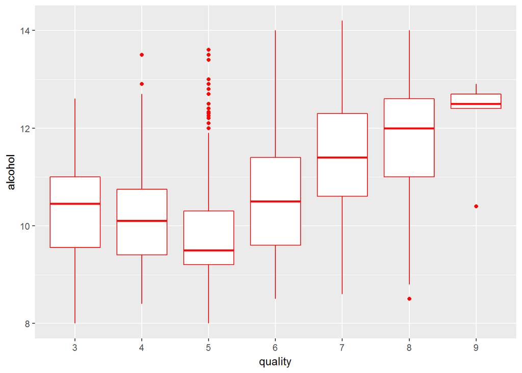

Summary of different alcohol% based on quality:

```
## df$quality: 3
##    Min. 1st Qu.  Median    Mean 3rd Qu.    Max.
##    8.00    9.55   10.45   10.35   11.00   12.60
## --------------------------------------------------------
## df$quality: 4
##    Min. 1st Qu.  Median    Mean 3rd Qu.    Max.
##    8.40    9.40   10.10   10.15   10.75   13.50
## --------------------------------------------------------
## df$quality: 5
##    Min. 1st Qu.  Median    Mean 3rd Qu.    Max.
##   8.000   9.200   9.500   9.809  10.300  13.600
## --------------------------------------------------------
## df$quality: 6
##    Min. 1st Qu.  Median    Mean 3rd Qu.    Max.
##    8.50    9.60   10.50   10.58   11.40   14.00
## --------------------------------------------------------
## df$quality: 7
##    Min. 1st Qu.  Median    Mean 3rd Qu.    Max.
##    8.60   10.60   11.40   11.37   12.30   14.20
## --------------------------------------------------------
## df$quality: 8
##    Min. 1st Qu.  Median    Mean 3rd Qu.    Max.
##    8.50   11.00   12.00   11.64   12.60   14.00
## --------------------------------------------------------
## df$quality: 9
##    Min. 1st Qu.  Median    Mean 3rd Qu.    Max.
##   10.40   12.40   12.50   12.18   12.70   12.90
```

> This boxplot and summary shows that the alcohol % increases as the quality increases. There is a steady increase in alcohol % from level 5 to 9. That is, higher quality wines have higher alcohol contents.

> let us plot a boxplot of different pH values of the different qualities and find the differences, if any.

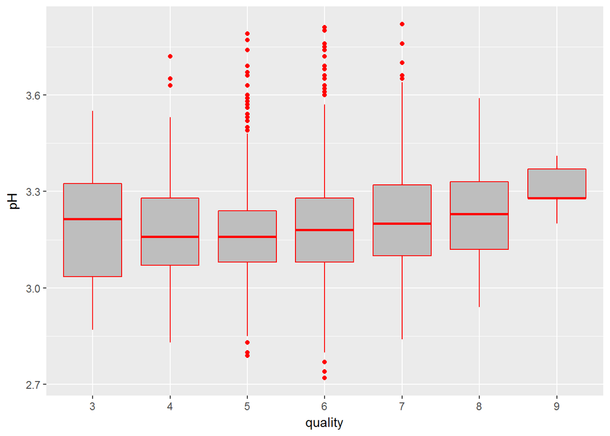

> It is somewhat similar to the above plot. Just like how alcohol% decreases from quality level 3 to 5 and then increases, median pH values follows the same trend. This means that there could be some kind of correlation between pH and alcohol%. Let us plot these 2 variables on a scatter plot and see if any correlation exists.

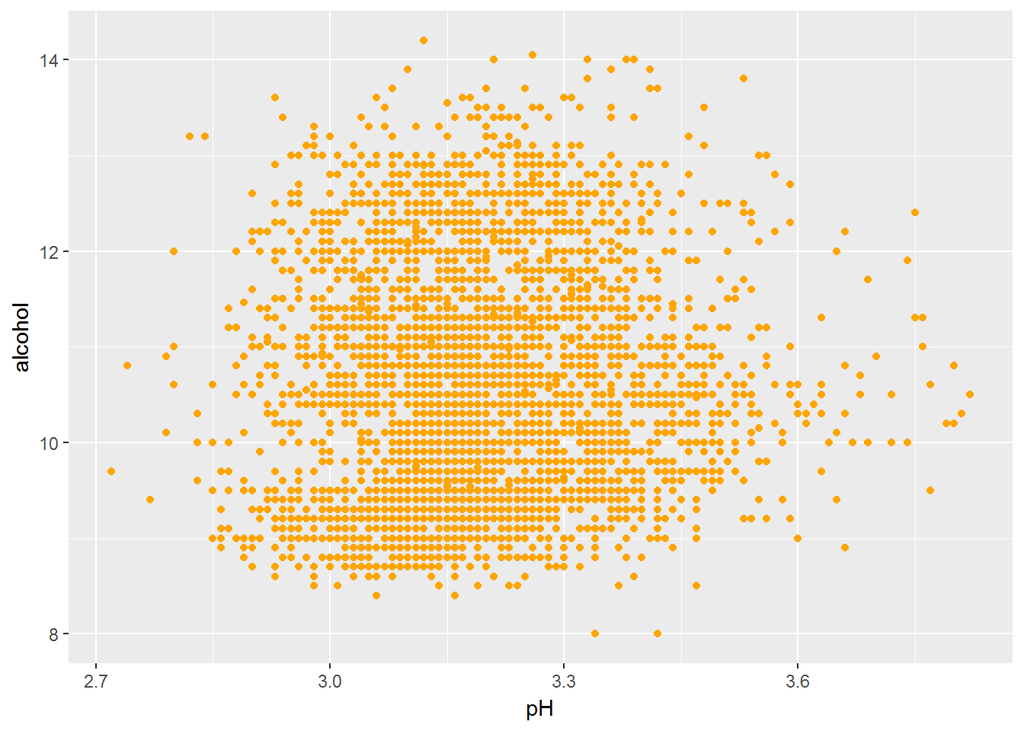

> The plot seems very spread out and dispersed. The correlation coefficient of these features must be quite low. It seems unlikely that any correlation exists; however we’ll find the pearson’s correlation coefficient anyway.

```
##
##  Pearson's product-moment correlation
##
## data:  df$pH and df$alcohol
## t = 8.5601, df = 4896, p-value < 2.2e-16
## alternative hypothesis: true correlation is not equal to 0
## 95 percent confidence interval:
##  0.09374446 0.14893205
## sample estimates:
##       cor
## 0.1214321
```

> The correlation is quite low in these two variables; so there isn’t any causation between the two, but these 2 variables do cause another variable(quality).

> Apart from that, we saw that higher quality wines have higher pH values(more basic). This could mean that higher quality wines have lesser acidic properties. Let us plot a box plot of fixed acidity against the qualities.

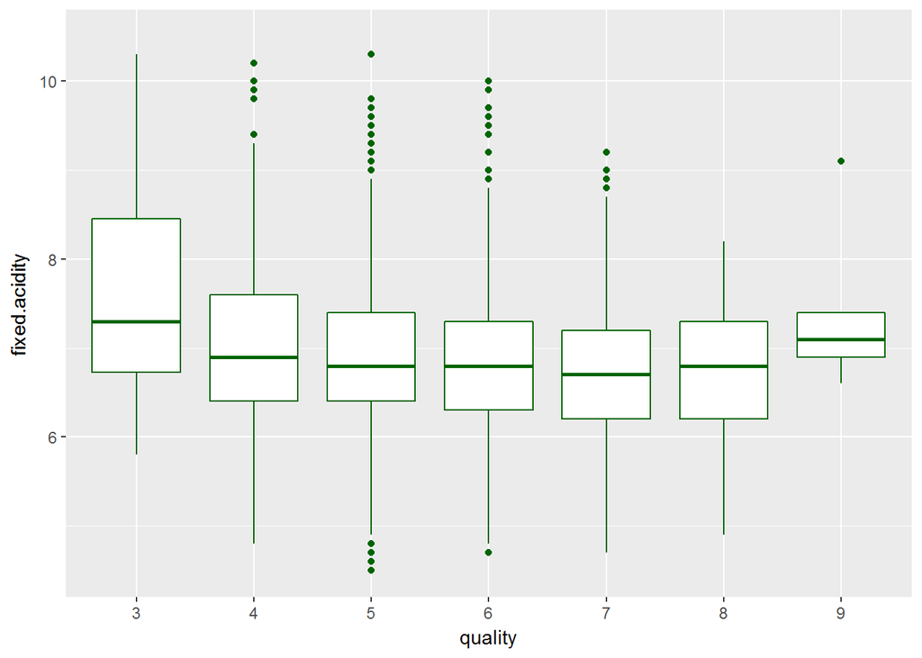

> There is a very small but appreciatable decrease in the fixed acidity levels, as the quality increases. However, it is not significant enough.

> Now lets plot free.sulfur.dioxide vs total.sulfur.dioxide . Without seeing the plot, we know that there must be a correlation between the two, as total sulfur dioxide takes account of the free sulfur dioxide already.

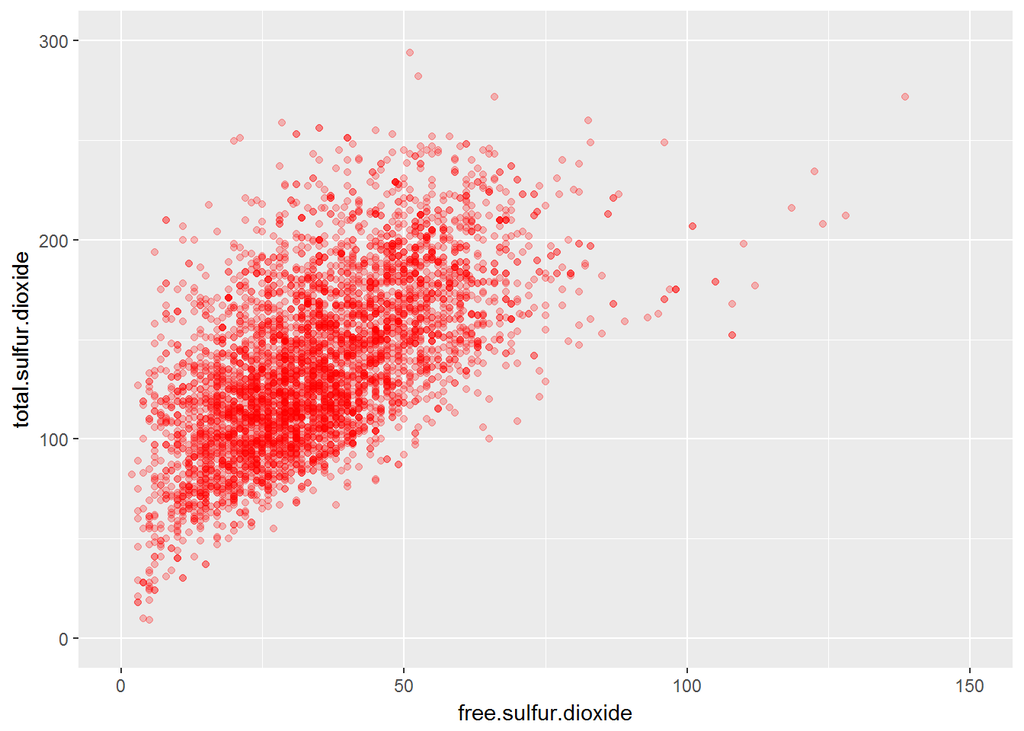

> Just as we felt, the plot does signify a strong correlation between the 2 features. Lets find the correlation coeficient between them.

```
##
##  Pearson's product-moment correlation
##
## data:  df$free.sulfur.dioxide and df$total.sulfur.dioxide
## t = 54.645, df = 4896, p-value < 2.2e-16
## alternative hypothesis: true correlation is not equal to 0
## 95 percent confidence interval:
##  0.5977994 0.6326026
## sample estimates:
##      cor
## 0.615501
```

> We can see that the correlation value is quite high. Hence we can conclude that there is a strong correlation between the two, and a causation of course, as total sulfur dioxides accounts for free and bound forms of SO2.

> Let us find the correlation between density and residual sugar, if any.

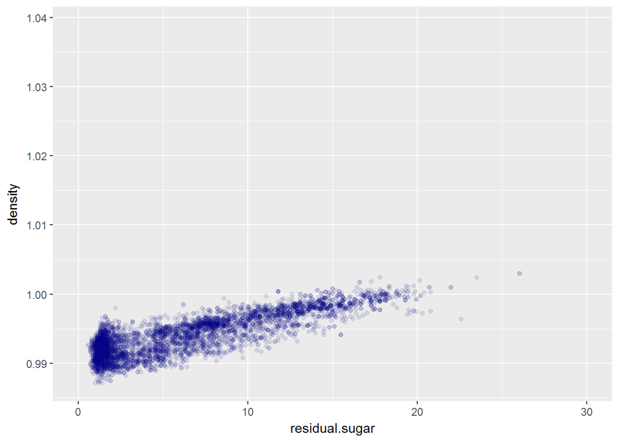

> It is pretty evident that there is a strong correlation between these 2 features. Let us find the correlation coefficient of the same.

```
##
##  Pearson's product-moment correlation
##
## data:  df$density and df$residual.sugar
## t = 107.87, df = 4896, p-value < 2.2e-16
## alternative hypothesis: true correlation is not equal to 0
## 95 percent confidence interval:
##  0.8304732 0.8470698
## sample estimates:
##       cor
## 0.8389665
```

> The correlation coefficient here is very high, which shows a strong correlation between density and residual sugar features.

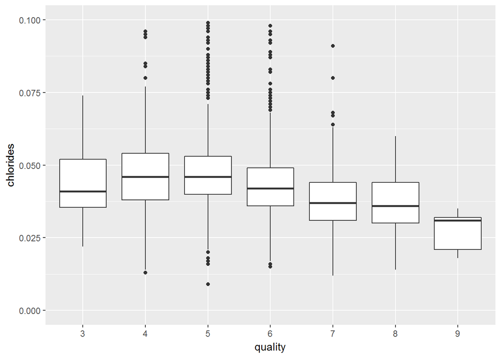

> There is a significant decrease in the chlorides level of white wine with the increase in quality.

> Let us plot density vs chlorides, as we had seen that like chlorides, density had also decreased with quality.

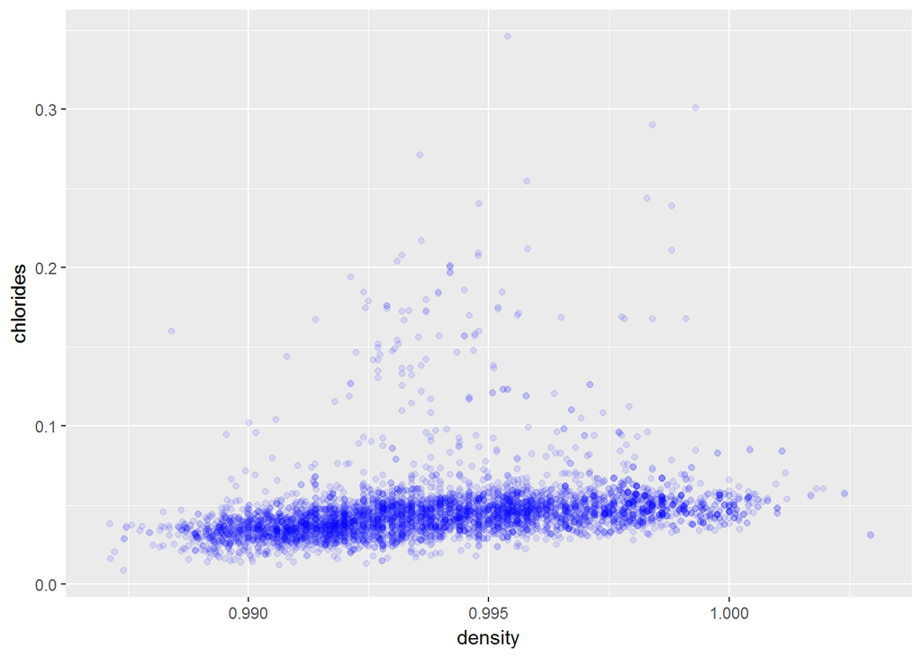

> We can see there is a region which is slightly overplotted, but also seems correlated. Let us find the correlation factor of the same.

```
##
##  Pearson's product-moment correlation
##
## data:  df$density and df$chlorides
## t = 18.624, df = 4896, p-value < 2.2e-16
## alternative hypothesis: true correlation is not equal to 0
## 95 percent confidence interval:
##  0.2308679 0.2831779
## sample estimates:
##       cor
## 0.2572113
```

> The correlation factor here is not significant of course, and hence we cannot conclude that the variables are correlated.

> Let us plot density vs alcohol and test its correlation.

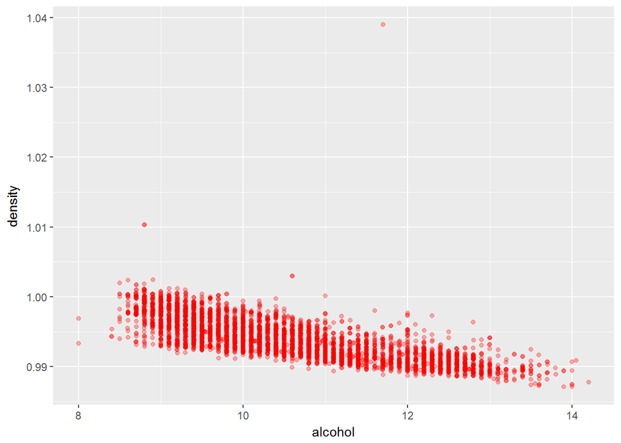

> It seems as if they are correlated very closely, let us find correlation factor to confirm this.

```
##
##  Pearson's product-moment correlation
##
## data:  df$alcohol and df$density
## t = -87.255, df = 4896, p-value < 2.2e-16
## alternative hypothesis: true correlation is not equal to 0
## 95 percent confidence interval:
##  -0.7908646 -0.7689315
## sample estimates:
##        cor
## -0.7801376
```

> As we can see the correlation factor is a negative high value, which means that they are strongely negatively correlated. Thus, we infer that as the alcohol% increases in the wine sample, its density decreases.

# Bivariate Analysis

### Talk about some of the relationships you observed in this part of the investigation. How did the feature(s) of interest vary with other features in the dataset?

> It is seen that higher qualities of white wine have got lower densities. Also, high qualities of wine also have higher values of pH and alcohol% than the other levels. 2 unusual distributions are there in pH and alcohol % values however. Generally both increases with the quality, however quality 3 and 4 have higher pH and alcohol% values than level 5 and hence going against the trend.

### What was the strongest relationship you found?

> The highest degree of correlation is found between residual sugar and density values.

# Multivariate Plots Section

> We’ve seen that higher quality of wine have got lower amounts of densities, while having pH and alcohol%. So let us plot alcohol vs pH for the different qualities first.

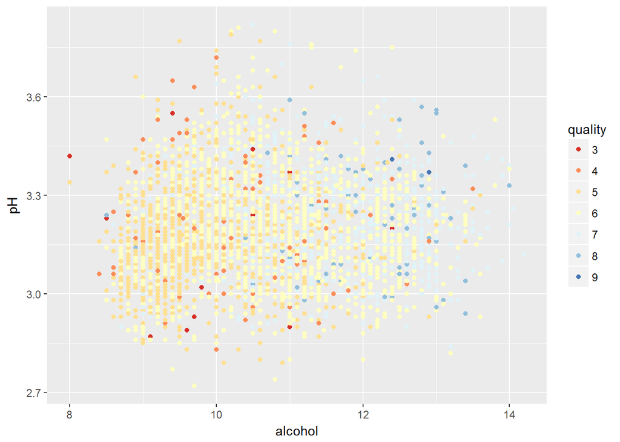

> Most blue spots, which correspond to high quality, are found at the right side of the scatter plot, which means high % alcohol. However, no visible trend is present corresponding to the pH values for lower or higher quality wines.

> Now let us plot density vs alcohol vs quality

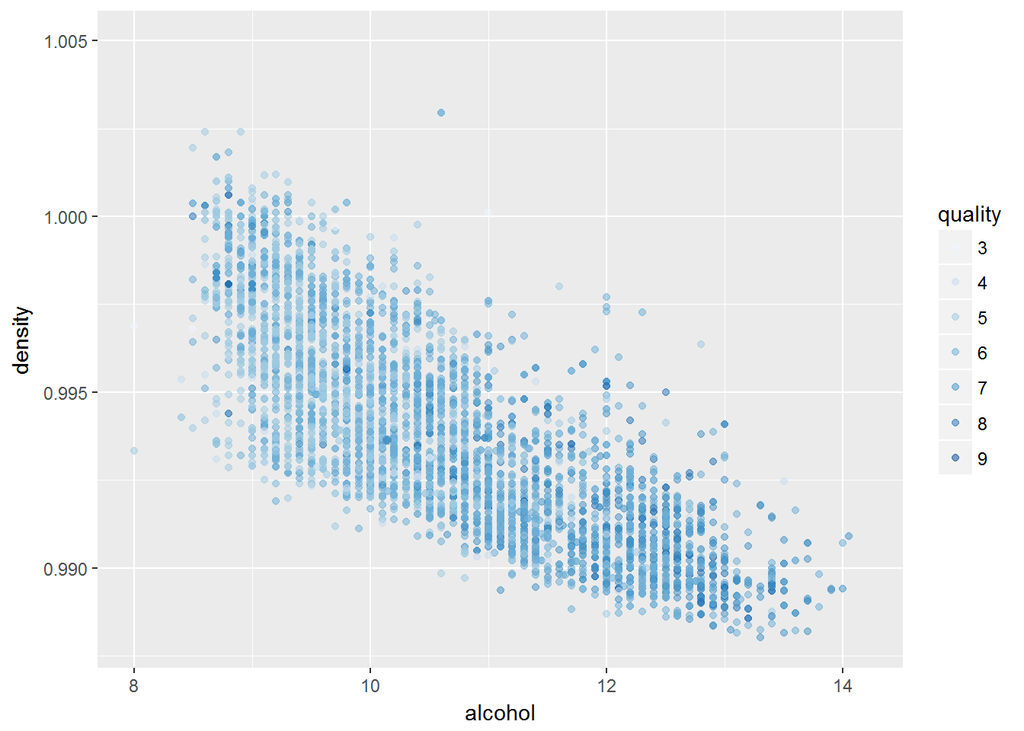

> This plot is spread out similar to the above plot. The lighter spots are concentrated to the left, and darker ones in the right of the scatter plot. Blue spots are to the right and below spots meaning high alcohol and lower densities, so high quality wines have higher qualities of wine and lower densities.

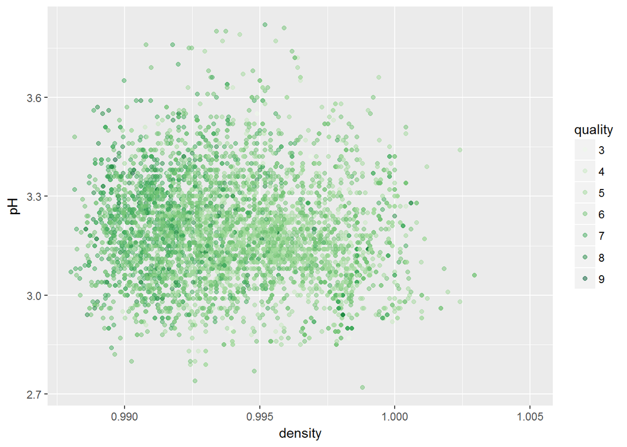

> It is somewhat hard to conclude something concrete from this plot, as the light green spots are all over the plot. However, we can see most darker spots are to the left of the plot, signifying lower density values for high quality wines.

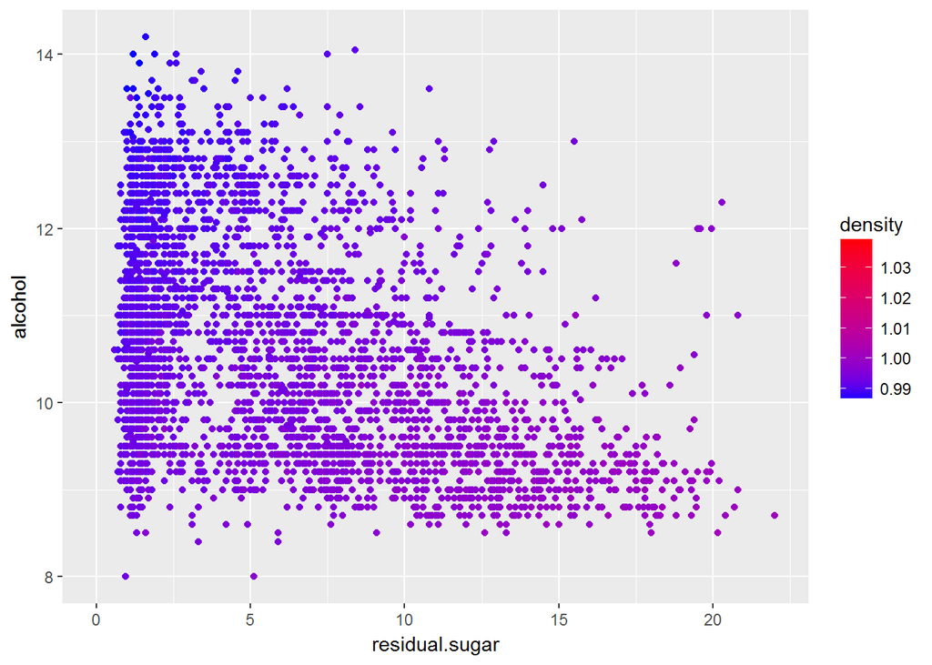

> In this plot, we see that pure blue colour spots are present only at the top left region, which means lowest values of density corresponds to high percentage of alcohol and low amounts of residual sugar. As the amount of sugar increases and alcohol decreases, the spot colour changes towards red, which means high density.

> It seems as if residual sugar and alcohol are good estimators for the density variable. Let’s try to fit a linear model to this.

```
##
## Call:
## lm(formula = density ~ alcohol + residual.sugar, data = df)
##
## Residuals:
##        Min         1Q     Median         3Q        Max
## -0.0020196 -0.0005852 -0.0001403  0.0004674  0.0249805
##
## Coefficients:
##                  Estimate Std. Error t value Pr(>|t|)
## (Intercept)     1.005e+00  1.349e-04  7446.7   <2e-16 ***
## alcohol        -1.226e-03  1.189e-05  -103.2   <2e-16 ***
## residual.sugar  3.607e-04  2.884e-06   125.1   <2e-16 ***
## ---
## Signif. codes:  0 '***' 0.001 '**' 0.01 '*' 0.05 '.' 0.1 ' ' 1
##
## Residual standard error: 0.0009137 on 4895 degrees of freedom
## Multiple R-squared:  0.9067, Adjusted R-squared:  0.9067
## F-statistic: 2.379e+04 on 2 and 4895 DF,  p-value: < 2.2e-16
```

> Just the alcohol and residual sugar variables account for 90% of variance in density variable.

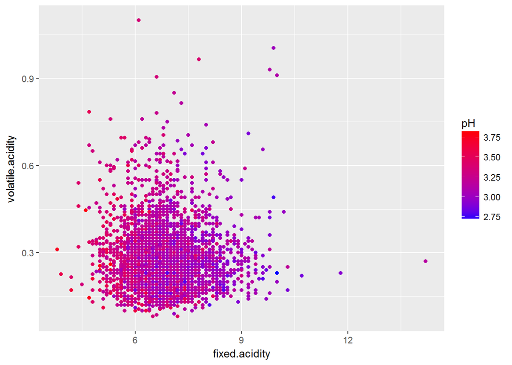

> We see here that the red spots are concentrated to the left and lower parts of the scatter plot, which means higher pH values have lower fixed and volatile acidity values. This is expected, as high pH values correspond to lesser acidic properties.

# Multivariate Analysis

### Talk about some of the relationships you observed in this part of the investigation. Were there features that strengthened each other in terms of looking at your feature(s) of interest?

> Not exactly strengthened, as most scatter plots which took on colours corresponding to quality levels were not linearly seperable. Generally it was visible that high quality wines have lower density, higher alcohol% and higher pH values.

### Were there any interesting or surprising interactions between features?

> Residual sugar and alcohol are major factors of density of a particular sample. A clear transition is seen in the scatter plot.

### OPTIONAL: Did you create any models with your dataset? Discuss the strengths and limitations of your model.

> Yes, I created a linear model starting from the residual sugar and the alcohol% to the density.

> The variables in the linear model account for 90.7% of the variance in the density of white wine. I have used only 2 variables in this model; there must be more variables which affect the density variable.

# Final Plots and Summary

### Plot One

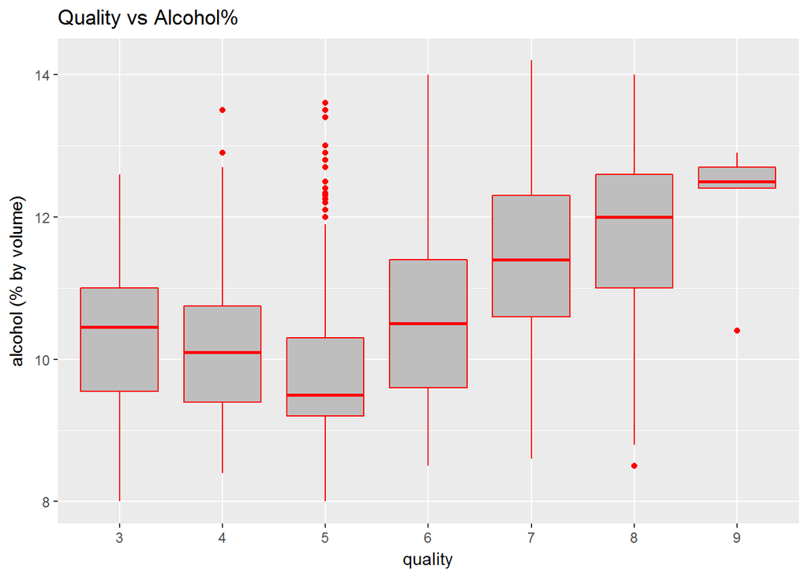

### Description One

What we observe here is the variation in alcohol% in the different quality levels of white wine. While there is a slight decrease from quality 3 to 5, from there it increases significantly to the highest quality.

### Plot Two

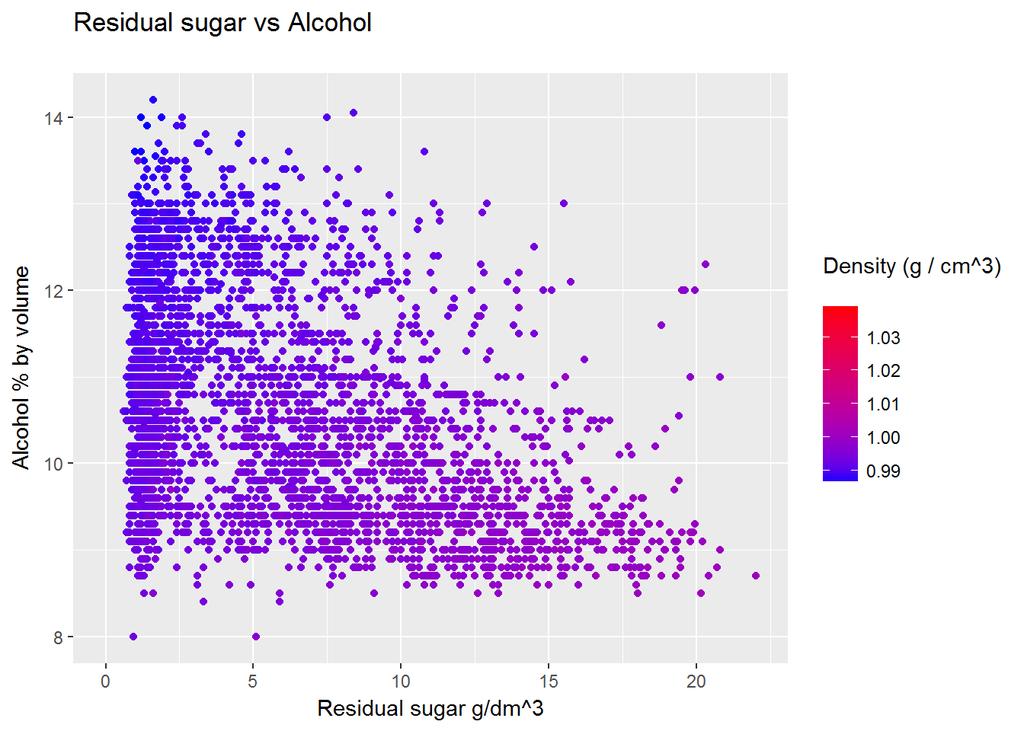